# Model Selection and Validation

Xanthe Walker

2025-08-05

## Introduction

In this workshop, we will explore **model selection and validation** using the `mammals.csv` dataset.

We will work through four approaches:

1. **Likelihood Ratio Tests for Minimum Adequate Model** using a structured 10-step protocol.
2. **Stepwise AIC** (demonstrated but not recommended).
3. **Model averaging** to incorporate model uncertainty.
4. **Cross-validation** to assess predictive performance.

## Load and inspect the data

We first load the dataset and select variables of interest, removing incomplete cases.

```r
mammals <- read.csv("../../Data files/mammals.csv")

mammalsc <- mammals %>%
  dplyr::select(total_sleep, life_span, gestation,
                brain_wt, body_wt, predation,
                exposure, danger, order) %>%
  filter(complete.cases(.))

str(mammalsc)
```

```
## 'data.frame':    51 obs. of  9 variables:
##  $ total_sleep: num  3.3 8.3 12.5 3.9 9.8 19.7 6.2 14.5 9.7 12.5 ...
##  $ life_span  : num  38.6 4.5 14 69 27 19 30.4 28 50 7 ...
##  $ gestation  : num  645 42 60 624 180 35 392 63 230 112 ...
##  $ brain_wt   : num  5712 6.6 44.5 4603 179.5 ...
##  $ body_wt    : num  6654 1 3.38 2547 10.55 ...
##  $ predation  : int  3 3 1 3 4 1 4 1 1 5 ...
##  $ exposure   : int  5 1 1 5 4 1 5 2 1 4 ...
##  $ danger     : int  3 3 1 4 4 1 4 1 1 4 ...
##  $ order      : int  5 6 3 4 4 3 3 5 1 2 ...
```

```r
summary(mammalsc)
```

```
##   total_sleep      life_span        gestation        brain_wt
##  Min.   : 2.60   Min.   :  2.00   Min.   : 12.0   Min.   :   0.14
##  1st Qu.: 7.30   1st Qu.:  6.25   1st Qu.: 42.0   1st Qu.:   4.50
##  Median :10.30   Median : 14.00   Median :100.0   Median :  21.00
##  Mean   :10.35   Mean   : 20.15   Mean   :142.1   Mean   : 317.50
##  3rd Qu.:13.20   3rd Qu.: 27.50   3rd Qu.:205.0   3rd Qu.: 172.00
##  Max.   :19.90   Max.   :100.00   Max.   :645.0   Max.   :5712.00
##     body_wt           predation        exposure         danger
##  Min.   :   0.005   Min.   :1.000   Min.   :1.000   Min.   :1.000
##  1st Qu.:   0.615   1st Qu.:2.000   1st Qu.:1.000   1st Qu.:1.000
##  Median :   3.385   Median :3.000   Median :2.000   Median :2.000
##  Mean   : 224.363   Mean   :2.843   Mean   :2.451   Mean   :2.627
##  3rd Qu.:  44.245   3rd Qu.:4.000   3rd Qu.:4.000   3rd Qu.:4.000
##  Max.   :6654.000   Max.   :5.000   Max.   :5.000   Max.   :5.000
##      order
##  Min.   :1.000
##  1st Qu.:2.000
##  Median :3.000
##  Mean   :3.549
##  3rd Qu.:5.000
##  Max.   :7.000
```

## Explore relationships between predictors

Before modeling, it’s important to look for collinearity between predictors.  
Here we use `GGally::ggpairs` to visualize scatterplots, correlations, and distributions for each variable.

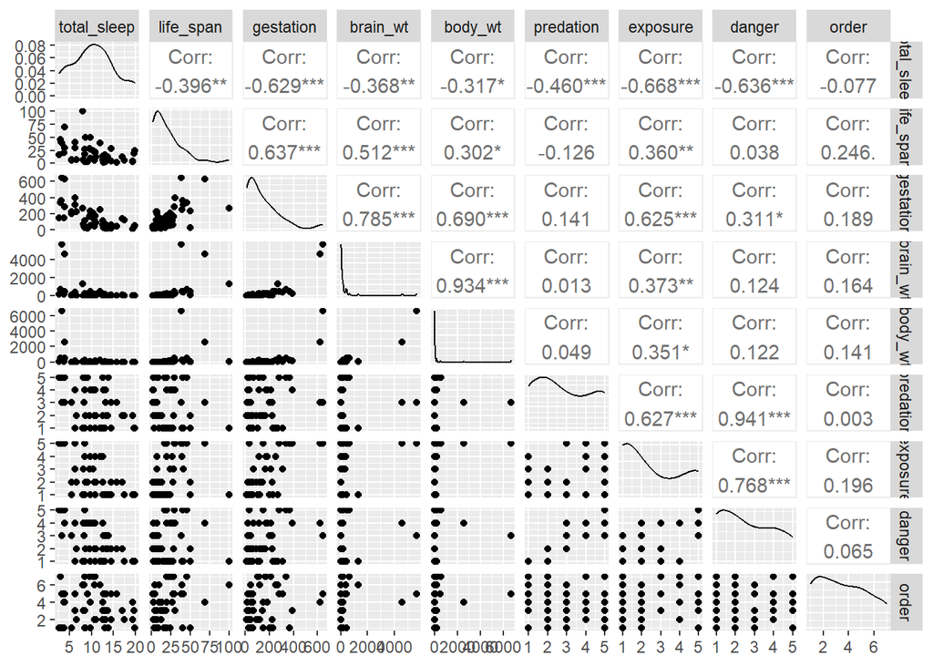

```r
GGally::ggpairs(mammalsc)
```

Predictor variables will almost always be correlated in observational studies.  
When these correlations are **strong**, it can be difficult to estimate parameters in a multiple regression model.  
This can lead to coefficients with **large standard errors** and unstable model estimates.

When deciding which predictors to include, consider:

- Are the predictors **ecologically relevant**?
- Are they **feasible to collect** in other studies?
- Are they **closer to the mechanism** underlying the response?
- **Rule of thumb:** have at least **10–20 observations per predictor** in regression.

### Strategies for handling collinearity

- **Keep all variables** if the focus is on prediction and collinearity does not cause instability.
- **Include collinear variables** if estimating causal effects and they each have separate direct effects on the response.
- **Drop one variable** from a set of highly correlated predictors (e.g., correlation > 0.7).
- **Compare univariate regressions** and choose the predictor with the strongest relationship to the response.
- **Stepwise model selection** (often drops collinear variables automatically — but be cautious, this can lead to overfitting).
- **Principal Components Analysis (PCA)** to combine correlated variables into composite predictors.
- **Structural Equation Modeling (SEM)** to model complex relationships explicitly.

### Checking collinearity in R

We can use the `performance` package to calculate **Variance Inflation Factors (VIF)** and assess collinearity.

```r
# Fit a simple model with all predictors for collinearity check
col_test <- lm(total_sleep ~ life_span + gestation + log(body_wt) + log(brain_wt) +
                 predation + exposure + danger, data = mammalsc)

performance::check_collinearity(col_test)
```

```
## # Check for Multicollinearity
##
## Low Correlation
##
##       Term  VIF     VIF 95% CI adj. VIF Tolerance Tolerance 95% CI
##  life_span 2.51 [ 1.84,  3.71]     1.58      0.40     [0.27, 0.54]
##  gestation 2.97 [ 2.14,  4.42]     1.72      0.34     [0.23, 0.47]
##
## Moderate Correlation
##
##      Term  VIF     VIF 95% CI adj. VIF Tolerance Tolerance 95% CI
##  exposure 5.12 [ 3.52,  7.74]     2.26      0.20     [0.13, 0.28]
##
## High Correlation
##
##           Term   VIF     VIF 95% CI adj. VIF Tolerance Tolerance 95% CI
##   log(body_wt) 13.90 [ 9.18, 21.37]     3.73      0.07     [0.05, 0.11]
##  log(brain_wt) 16.57 [10.89, 25.50]     4.07      0.06     [0.04, 0.09]
##      predation 12.98 [ 8.58, 19.93]     3.60      0.08     [0.05, 0.12]
##         danger 16.73 [11.00, 25.76]     4.09      0.06     [0.04, 0.09]
```

VIF values above **5** (sometimes above **10**) may indicate problematic collinearity, especially if the goal is to estimate effect sizes precisely.

> **Remember:** Collinearity is not inherently “bad” — it’s a problem when it prevents you from answering your research question or leads to unstable model estimates.

# 1. Likelihood Ratio Tests for Minimum Adequate Model (10-Step Protocol)

We will follow this process:

1. **Fit a linear regression.**
2. **Fit a GLS model** (baseline for comparison).
3. **Choose variance structure** (if needed).
4. **Fit the mixed-effects model** (REML).
5. **Compare models** (GLS vs LME).
6. **Validate model** (diagnostics).
7. **Find optimal fixed effects** – drop interactions first, then main effects.
8. **Repeat selection** until the best fixed structure is found.
9. **Refit with REML** and validate.
10. **Interpret results**.

### Step 1: Fit a linear regression

We start with a simple multiple regression (`lm`) assuming no random effects and constant variance.

```r
lm1 <- lm(total_sleep ~ life_span + gestation + log(body_wt) + danger, data = mammalsc)
summary(lm1)
```

```
##
## Call:
## lm(formula = total_sleep ~ life_span + gestation + log(body_wt) +
##     danger, data = mammalsc)
##
## Residuals:
##     Min      1Q  Median      3Q     Max
## -7.0801 -1.8721  0.3026  1.6662  5.1498
##
## Coefficients:
##               Estimate Std. Error t value Pr(>|t|)
## (Intercept)  16.489266   1.037546  15.893  < 2e-16 ***
## life_span    -0.013473   0.030591  -0.440   0.6617
## gestation    -0.008013   0.004838  -1.656   0.1045
## log(body_wt) -0.380149   0.214318  -1.774   0.0827 .
## danger       -1.610177   0.312936  -5.145 5.39e-06 ***
## ---
## Signif. codes:  0 '***' 0.001 '**' 0.01 '*' 0.05 '.' 0.1 ' ' 1
##
## Residual standard error: 2.911 on 46 degrees of freedom
## Multiple R-squared:  0.6439, Adjusted R-squared:  0.613
## F-statistic:  20.8 on 4 and 46 DF,  p-value: 7.662e-10
```

### Step 2: Fit a GLS model

A GLS model allows us to compare with future mixed models and adjust variance structures if needed.

```r
gls1 <- gls(total_sleep ~ life_span + gestation + log(body_wt) + danger,
            data = mammalsc)
summary(gls1)
```

```
## Generalized least squares fit by REML
##   Model: total_sleep ~ life_span + gestation + log(body_wt) + danger
##   Data: mammalsc
##        AIC      BIC    logLik
##   277.5863 288.5582 -132.7932
##
## Coefficients:
##                  Value Std.Error   t-value p-value
## (Intercept)  16.489266 1.0375461 15.892562  0.0000
## life_span    -0.013473 0.0305911 -0.440408  0.6617
## gestation    -0.008013 0.0048382 -1.656240  0.1045
## log(body_wt) -0.380149 0.2143182 -1.773762  0.0827
## danger       -1.610177 0.3129355 -5.145396  0.0000
##
##  Correlation:
##              (Intr) lf_spn gesttn lg(b_)
## life_span    -0.475
## gestation    -0.120 -0.331
## log(body_wt)  0.383 -0.340 -0.550
## danger       -0.742  0.243 -0.248 -0.112
##
## Standardized residuals:
##        Min         Q1        Med         Q3        Max
## -2.4320106 -0.6430753  0.1039459  0.5723269  1.7689453
##
## Residual standard error: 2.911199
## Degrees of freedom: 51 total; 46 residual
```

### Step 3 and 4: Choose a Variance (or Random effect) Structure and fit the model

Check residual patterns to see if variance changes with predictors or groups.  
If heteroscedasticity is present, we can specify variance functions.

We add **Order** as a random intercept to account for species being grouped by order.

```r
lme1 <- lme(total_sleep ~ life_span + gestation + log(body_wt) + danger,
            random = ~ 1 | order,
            data = mammalsc,
            method = "REML")
summary(lme1)
```

```
## Linear mixed-effects model fit by REML
##   Data: mammalsc
##        AIC      BIC    logLik
##   278.8169 291.6174 -132.4084
##
## Random effects:
##  Formula: ~1 | order
##         (Intercept) Residual
## StdDev:   0.7873472 2.809503
##
## Fixed effects:  total_sleep ~ life_span + gestation + log(body_wt) + danger
##                  Value Std.Error DF   t-value p-value
## (Intercept)  16.447294 1.0567238 40 15.564421  0.0000
## life_span    -0.007896 0.0302221 40 -0.261259  0.7952
## gestation    -0.007808 0.0047542 40 -1.642316  0.1084
## log(body_wt) -0.405906 0.2110018 40 -1.923707  0.0615
## danger       -1.619015 0.3056475 40 -5.297002  0.0000
##  Correlation:
##              (Intr) lf_spn gesttn lg(b_)
## life_span    -0.466
## gestation    -0.094 -0.342
## log(body_wt)  0.339 -0.317 -0.556
## danger       -0.708  0.244 -0.261 -0.090
##
## Standardized Within-Group Residuals:
##        Min         Q1        Med         Q3        Max
## -2.2438671 -0.6650256  0.1035455  0.7306677  1.7647895
##
## Number of Observations: 51
## Number of Groups: 7
```

### Step 5: Compare new mixed-effects model with old

Compare models using maximum likelihood to see if adding random effects improves fit.

```r
gls1_ml <- update(gls1, method = "ML")
lme1_ml <- update(lme1, method = "ML")
anova(gls1_ml, lme1_ml)
```

```
##         Model df      AIC      BIC    logLik   Test   L.Ratio p-value
## gls1_ml     1  6 260.4630 272.0539 -124.2315
## lme1_ml     2  7 261.9292 275.4520 -123.9646 1 vs 2 0.5337638   0.465
```

### Step 6: Validate model

Check for assumption violations:  
- Homogeneity of residuals.  
- Normality.  
- Outliers.

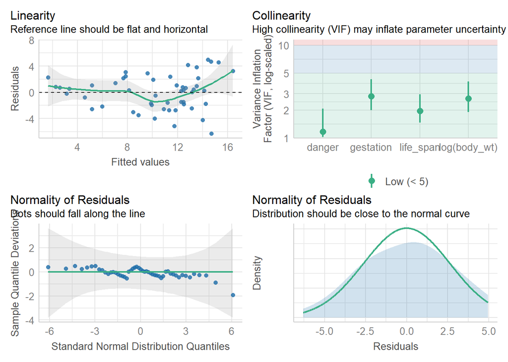

```r
check_model(lme1)
```

### Steps 7 & 8: Find optimal fixed effects structure

First drop interaction terms (if present), then drop main effects one at a time, comparing models with likelihood ratio tests.

```r
lme1_ml <- update(lme1, method = "ML")
drop1(lme1_ml, test = "Chisq")
```

```
## Single term deletions
##
## Model:
## total_sleep ~ life_span + gestation + log(body_wt) + danger
##              Df    AIC     LRT  Pr(>Chi)
## <none>          261.93
## life_span     1 260.02  0.0939   0.75922
## gestation     1 262.85  2.9188   0.08755 .
## log(body_wt)  1 263.67  3.7390   0.05316 .
## danger        1 283.63 23.7053 1.123e-06 ***
## ---
## Signif. codes:  0 '***' 0.001 '**' 0.01 '*' 0.05 '.' 0.1 ' ' 1
```

### Step 9: Refit with REML and validate

After selecting the optimal fixed structure, refit the model using REML for final coefficient estimates.

```r
lme_final <- update(lme1, fixed = total_sleep ~ danger,
                    method = "REML")
summary(lme_final)
```

```
## Linear mixed-effects model fit by REML
##   Data: mammalsc
##        AIC      BIC    logLik
##   281.5684 289.1357 -136.7842
##
## Random effects:
##  Formula: ~1 | order
##         (Intercept) Residual
## StdDev:    1.053123  3.50894
##
## Fixed effects:  total_sleep ~ danger
##                 Value Std.Error DF   t-value p-value
## (Intercept) 15.799160 1.1227627 43 14.071683       0
## danger      -2.075962 0.3526352 43 -5.886994       0
##  Correlation:
##        (Intr)
## danger -0.823
##
## Standardized Within-Group Residuals:
##         Min          Q1         Med          Q3         Max
## -2.08585226 -0.63954920 -0.08756313  0.78424686  1.98997561
##
## Number of Observations: 51
## Number of Groups: 7
```

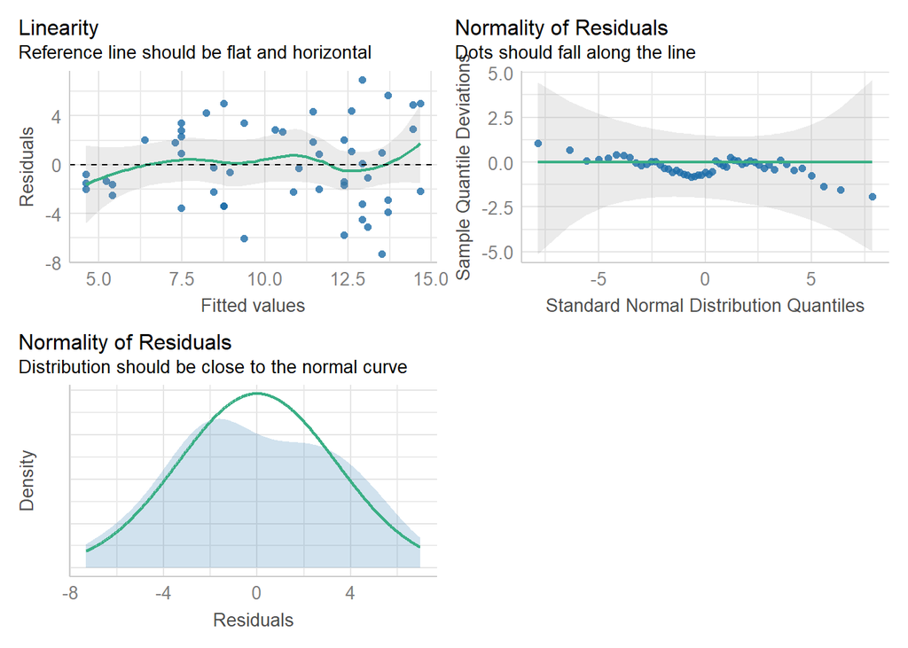

```r
check_model(lme_final)
```

### Step 10: Interpret

Interpret coefficients, p-values, and R² (marginal and conditional).

```r
tab_model(lme_final, show.se=TRUE)
```

|  | total_sleep |  |  |  |
| --- | --- | --- | --- | --- |
| Predictors | Estimates | std. Error | CI | p |
| (Intercept) | 15.80 | 1.12 | 13.53 – 18.06 | **<0.001** |
| danger | -2.08 | 0.35 | -2.79 – -1.36 | **<0.001** |
| Random Effects |  |  |  |  |
| σ<sup>2</sup> | 12.31 |  |  |  |
| τ<sub>00</sub> <sub>order</sub> | 1.11 |  |  |  |
| ICC | 0.08 |  |  |  |
| N <sub>order</sub> | 7 |  |  |  |
| Observations | 51 |  |  |  |
| Marginal R<sup>2</sup> / Conditional R<sup>2</sup> | 0.396 / 0.446 |  |  |  |

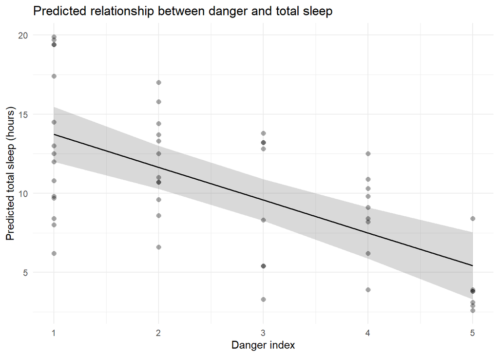

```r
# Get predicted values from the model for danger
pred <- ggeffects::ggpredict(lme_final, terms = "danger")

# Plot predictions with confidence intervals
plot(pred, show_data = TRUE) +
  labs(x = "Danger index",
       y = "Predicted total sleep (hours)",
       title = "Predicted relationship between danger and total sleep") +
  theme_minimal()
```

# 2. Stepwise AIC

Using **stepwise elimination** or **addition** of terms is a common practice — but also **highly criticized**.

Stepwise model selection involves:

- Fitting a multiple regression with many variables.
- Iteratively adding or deleting terms, refitting the model each time.
- Continuing until only “statistically significant” terms remain.

## How it works

- **`MASS` package**: `stepAIC()` function (`direction = "backward"`, `"forward"`, or `"both"`).
- **`lmerTest` package**: `step()` function (can step through both random and fixed effects).

> **Note:** A **Likelihood Ratio Test (LRT)** of full vs reduced models is **not** the same as backward stepwise selection.  
> `drop1()` drops one term at a time and tests each against the full model.  
> The `step()` or `stepAIC()` function will drop the “worst” term (or add the “best”), then repeat the process iteratively.

### Backward selection:

1. Fit a full model containing all predictors of interest.
2. Consider all possible models formed by dropping one of these predictors.
3. Keep the current model, or drop the “worst” predictor depending on:
   - Highest p-value (> 0.05)
   - Adjusted R² (higher is better) for `lm`
   - AIC (lower is better) for `lme`
4. Repeat until no improvement is possible.

### Forward selection:

1. Fit a null model containing no predictors.
2. Consider all possible models formed by adding 1 predictor at a time.
3. Keep the current model, or add the predictor based on comparisons between nested models.
4. Repeat until no improvement is possible.

Here, we will use the **same model** as before with `life_span`, `gestation`, `log(body_wt)`, and `danger`, and run `stepAIC()`.

The **default** direction is backward selection.

```r
step_model <- stepAIC(lme1_ml, direction = "backward")
```

```
## Start:  AIC=261.93
## total_sleep ~ life_span + gestation + log(body_wt) + danger
##
##                Df    AIC
## - life_span     1 260.02
## <none>            261.93
## - gestation     1 262.85
## - log(body_wt)  1 263.67
## - danger        1 283.63
##
## Step:  AIC=260.02
## total_sleep ~ gestation + log(body_wt) + danger
##
##                Df    AIC
## <none>            260.02
## - gestation     1 261.67
## - log(body_wt)  1 262.69
## - danger        1 282.13
```

```r
summary(step_model)
```

```
## Linear mixed-effects model fit by maximum likelihood
##   Data: mammalsc
##        AIC      BIC    logLik
##   260.0231 271.6141 -124.0116
##
## Random effects:
##  Formula: ~1 | order
##         (Intercept) Residual
## StdDev:   0.6750079 2.682915
##
## Fixed effects:  total_sleep ~ gestation + log(body_wt) + danger
##                  Value Std.Error DF   t-value p-value
## (Intercept)  16.312634 0.9204257 41 17.722923  0.0000
## gestation    -0.008301 0.0044363 41 -1.871219  0.0685
## log(body_wt) -0.421720 0.1982414 41 -2.127306  0.0395
## danger       -1.595795 0.2943318 41 -5.421756  0.0000
##  Correlation:
##              (Intr) gesttn lg(b_)
## gestation    -0.309
## log(body_wt)  0.234 -0.746
## danger       -0.700 -0.193 -0.016
##
## Standardized Within-Group Residuals:
##        Min         Q1        Med         Q3        Max
## -2.3585972 -0.7311928  0.1156880  0.7580442  1.9023655
##
## Number of Observations: 51
## Number of Groups: 7
```

### Reading the output

- The first table shows the current “best” model (`<none>`), indicating no variables have been dropped yet, compared to all possible models with one fewer predictor.
- Sorted from lowest (best fitting) to highest (worst fitting) AIC.
- If removing a variable results in a **lower** AIC, it is dropped.

For example:  
- Removing `life_span` might lower the AIC from 261 to 260 — stepAIC will drop it.  
- The final model keeps the remaining predictors because removing any of them would **increase** AIC.

### Key takeaways:

- `stepAIC()` is **more conservative** than some backward selection methods — less likely to drop variables quickly.
- It may keep more predictors than backward selection by LRT, leading to **more complex models**.
- The results are **not** the same as the LRT-based full vs reduced model comparisons.
- For **inference**, LRT-based model selection is generally preferred.
- For **exploration**, stepwise selection can be used — but not if you claim it is hypothesis testing!
- Always be transparent about your method and why you chose it.

# 3. Model Averaging (Multi-Model Inference)

The **Akaike Information Criterion (AIC)** is often used to choose among competing models, not just nested models.  
AIC balances **model fit** with **model complexity** — the best model has the **lowest AIC**.

## Why use model averaging?

Rather than selecting a single “best” model, we can average predictions or parameter estimates among multiple “good” models.  
This incorporates **model uncertainty** into our estimates by weighting each model’s parameters by that model’s Akaike weight.

### Steps for model averaging

1. Write down all **biologically plausible** models (or fit all subsets of predictors).
2. Fit each model and calculate AIC for each.
3. Compute **Akaike weights** from AIC values — these reflect the *relative plausibility* of each model.
4. Identify the **model set** based on a ΔAIC threshold (commonly ≤ 4 or ≤ 6 from the best model).
5. Calculate weighted predictions and SEs that reflect both model uncertainty and sampling uncertainty.

## How it works in practice

Here, we use the `MuMIn::dredge()` function, which returns all possible subsets of the starting model, ranked by AIC.

```r
# Generate all subsets of the full ML model
all_models <- dredge(lme1_ml)

# View the top models
all_models
```

```
## Global model call: lme.formula(fixed = total_sleep ~ life_span + gestation + log(body_wt) +
##     danger, data = mammalsc, random = ~1 | order, method = "ML")
## ---
## Model selection table
##    (Int)    dng       gst   lif_spn log(bdy_wt) df   logLik  AICc delta weight
## 12 16.31 -1.596 -0.008301               -0.4217  6 -124.012 261.9  0.00  0.382
## 10 15.79 -1.706                         -0.6983  5 -125.834 263.0  1.07  0.224
## 4  16.77 -1.604 -0.015410                        5 -126.343 264.0  2.09  0.134
## 16 16.46 -1.616 -0.007851 -0.008982     -0.4008  7 -123.965 264.5  2.60  0.104
## 14 16.28 -1.748           -0.025710     -0.5949  6 -125.424 264.8  2.82  0.093
## 8  17.17 -1.671 -0.012810 -0.029300              6 -125.834 265.6  3.65  0.062
## 6  17.55 -2.038           -0.091250              5 -130.603 272.5 10.61  0.002
## 2  15.80 -2.076                                  4 -137.083 283.0 21.10  0.000
## 11 12.79        -0.013060               -0.4458  5 -136.067 283.5 21.53  0.000
## 3  13.28        -0.020650                        4 -137.718 284.3 22.37  0.000
## 15 12.52        -0.014210  0.025620     -0.5039  6 -135.817 285.5 23.61  0.000
## 9  11.52                                -0.8944  4 -138.860 286.6 24.66  0.000
## 7  13.26        -0.020850  0.002455              5 -137.716 286.8 24.83  0.000
## 13 11.54                  -0.001159     -0.8899  5 -138.860 289.1 27.12  0.000
## 5  12.31                  -0.097420              4 -146.207 301.3 39.35  0.000
## 1  10.36                                         3 -150.524 307.6 45.63  0.000
## Models ranked by AICc(x)
## Random terms (all models):
##   1 | order
```

The list is sorted by AIC from “best” to “worst.”  
For example, the model containing `danger`, `gestation`, and `log(body_wt)` might have the smallest AIC and thus the largest weight.  
Several other models may have similar AIC values and moderate weights.

## Selecting models to average

We generally avoid averaging across models with negligible support (very low weights).  
Instead, we select all models within a certain ΔAIC threshold of the best model — here we’ll use ΔAIC ≤ 4.

```r
# Average only models within delta < 4
avg_model <- model.avg(all_models, subset = delta < 4)
summary(avg_model)
```

```
##
## Call:
## model.avg(object = all_models, subset = delta < 4)
##
## Component model call:
## lme.formula(fixed = total_sleep ~ <6 unique rhs>, data = mammalsc,
##      random = ~1 | order, method = ML)
##
## Component models:
##      df  logLik   AICc delta weight
## 124   6 -124.01 261.93  0.00   0.38
## 14    5 -125.83 263.00  1.07   0.22
## 12    5 -126.34 264.02  2.09   0.13
## 1234  7 -123.96 264.53  2.60   0.10
## 134   6 -125.42 264.76  2.82   0.09
## 123   6 -125.83 265.58  3.65   0.06
##
## Term codes:
##       danger    gestation    life_span log(body_wt)
##            1            2            3            4
##
## Model-averaged coefficients:
## (full average)
##               Estimate Std. Error Adjusted SE z value Pr(>|z|)
## (Intercept)  16.323477   1.019006    1.045852  15.608   <2e-16 ***
## danger       -1.642499   0.304540    0.313439   5.240    2e-07 ***
## gestation    -0.006857   0.006328    0.006387   1.074    0.283
## log(body_wt) -0.414811   0.285718    0.288596   1.437    0.151
## life_span    -0.005139   0.017990    0.018380   0.280    0.780
##
## (conditional average)
##               Estimate Std. Error Adjusted SE z value Pr(>|z|)
## (Intercept)  16.323477   1.019006    1.045852  15.608   <2e-16 ***
## danger       -1.642499   0.304540    0.313439   5.240    2e-07 ***
## gestation    -0.010041   0.005163    0.005269   1.906   0.0567 .
## log(body_wt) -0.516198   0.221927    0.226515   2.279   0.0227 *
## life_span    -0.019841   0.030949    0.031821   0.624   0.5329
## ---
## Signif. codes:  0 '***' 0.001 '**' 0.01 '*' 0.05 '.' 0.1 ' ' 1
```

## Interpreting averaged coefficients

The output shows two sets of coefficients:

- **Full average**: Assigns 0 to predictors not present in a given model before averaging — shrinks weak parameters toward zero (more conservative; recommended for interpretation).
- **Conditional average**: Averages only across models where the predictor is included — can give larger effect sizes for predictors with low support.

> **Best practice**: Use the **full average** for inference, as it guards against overestimating the importance of weak predictors.

## Key points

- **Exploratory** use: All-subsets selection of huge models (with many predictors/interactions) can overfit and include uninformative parameters.
- **Inference** use: Limit candidate models to a small set that reflect clear, biologically motivated hypotheses.
- Be explicit in your methods about the ΔAIC threshold and model selection process.
- In our example, model averaging suggests that only `danger` is consistently important across plausible models.

# 4. Cross-Validation

To evaluate the performance of a model, we need to measure how well the predictions made by the model match the observed data.

There are several common cross-validation designs:

1. **Refit the model on a new dataset**
   - Train model on one dataset
   - Test model predictions on a completely independent dataset
2. **Split data into training and testing datasets**
   - Randomly subset a percentage (e.g., 50%) of observations
   - For grouped data (with random effects):
     - Train model on all data from a subset of groups (e.g., 6 sites), test on the remaining group
     - Alternatively, split data within each group so part goes to training and part to testing
3. **Leave-one-out cross-validation (LOO)**
   - Train model on all but one observation, test on the held-out observation
   - Repeat for every observation in the dataset

## k-fold cross-validation

A common approach is **k-fold CV**:

- Partition the data into *k* subsets (“folds”)
- Train the model on *k-1* folds, test on the remaining fold
- Repeat until each fold has served as the test set once
- Pool results to estimate model fit (e.g., cross-validated R² or RMSE)

**Repeated k-fold CV** reduces variability in the evaluation and is useful for small datasets.

## When to use which approach

- **Small datasets** → Repeated k-fold CV is more reliable
- **Stable model performance & large dataset** → Regular k-fold CV may be sufficient
- **LOO CV** → Every observation is tested, but can be computationally expensive

## Using the `performance` package

We can easily compute CV metrics using the `performance` package.

First, we look at basic performance metrics for the model:

```r
performance(lme_final)
```

```
## # Indices of model performance
##
## AIC     |    AICc |     BIC | R2 (cond.) | R2 (marg.) |   ICC |  RMSE | Sigma
## -----------------------------------------------------------------------------
## 281.568 | 282.438 | 289.296 |      0.446 |      0.396 | 0.083 | 3.358 | 3.509
```

Then we perform **k-fold cross-validation** (here, k = 5):

⚠ **Important note on scaling predictors:**  
If you use the `performance` package for CV, you cannot keep `scale()` calls directly in your model formula (e.g., `y ~ scale(x)`).  
Instead, scale your predictors beforehand and use the scaled columns in the model.  
This avoids errors during cross-validation because `performance_cv()` refits the model internally.

- `stack = FALSE` means performance is computed within each fold, then averaged across folds
- `method = "k_fold"` can be replaced with `"loo"` (leave-one-out) or `"holdout"`

```r
set.seed(123)
performance_cv(lme_final, method = "k_fold", k = 5, stack = FALSE)
```

```
## # Cross-validation performance (5-fold method)
##
## MSE | MSE_SE | RMSE | RMSE_SE |   R2 | R2_SE
## --------------------------------------------
## 15  |    3.5 |  3.8 |     0.5 | 0.13 |  0.61
```

## Interpreting CV metrics

- **R²**: Squared correlation between observed and predicted values. Higher = better.
  - **Marginal R²** (from `performance()`): proportion of variance explained by **fixed effects** only.
  - **Conditional R²**: proportion explained by **both fixed and random effects**.
  - **Cross‑validated R²** (from `performance_cv()`): how much variance is explained when predicting unseen folds.
- **RMSE**: Root Mean Squared Error — average prediction error, in the same units as the response. Lower = better.
- **MSE**: Mean Squared Error — same as RMSE but squared; more sensitive to large errors.

**What is good?**  
- Depends on the scale of your outcome and how much error is acceptable.  
- Compare **CV metrics** to **in‑sample metrics**:  
- If CV R² is much lower than in‑sample R² → model may not generalize well (possible overfitting).  
- If CV RMSE is much higher than in‑sample RMSE → predictions are less accurate on new data.

**Example from our model:**  
- **In‑sample**: Marginal R² ≈ 0.40, RMSE ≈ 3.36 hours → model explains ~40% of variance, with moderate prediction error on training data.  
- **Cross‑validated**: R² ≈ 0.13, RMSE ≈ 3.8 hours → when predicting unseen folds, variance explained drops sharply, and prediction error increases slightly.  
- This gap suggests the model’s fixed effects have limited predictive power for new observations — it may be overfitting or missing important predictors.

**MSE/RMSE rules of thumb:**  
- MSE close to 0 → good fit.  
- MSE increases exponentially with error size.  
- RMSE is easier to interpret because it’s in the same units as the response variable. —

## Grouped k-fold cross-validation for mixed models

When working with mixed models, we must avoid splitting data from the same group into both training and test sets.  
Here, we’ll implement **manual grouped k‑fold cross-validation** so that all observations from a given `order` are assigned to the same fold.

```r
library(lme4)

set.seed(123)

# Number of folds
k <- 5

# Get unique groups and randomly assign them to folds
groups <- unique(mammalsc$order)
fold_assignments <- sample(rep(1:k, length.out = length(groups)))
names(fold_assignments) <- groups

# Data frame to store results
cv_results <- data.frame(Fold = integer(), R2 = numeric(), RMSE = numeric())

# Loop through folds
for (fold in 1:k) {

  # Identify test and train groups
  test_groups <- names(fold_assignments[fold_assignments == fold])
  train_data <- mammalsc[!mammalsc$order %in% test_groups, ]
  test_data  <- mammalsc[mammalsc$order %in% test_groups, ]

  # Fit the mixed model on the training data
  model <- lmer(total_sleep ~ life_span + gestation + log(body_wt) + danger + (1|order),
                data = train_data)

  # Predict on the test data
  preds <- predict(model, newdata = test_data, allow.new.levels = TRUE)

  # Calculate R² and RMSE for this fold
  ss_res <- sum((test_data$total_sleep - preds)^2)
  ss_tot <- sum((test_data$total_sleep - mean(test_data$total_sleep))^2)
  r2 <- 1 - (ss_res / ss_tot)
  rmse <- sqrt(mean((test_data$total_sleep - preds)^2))

  # Store results
  cv_results <- rbind(cv_results, data.frame(Fold = fold, R2 = r2, RMSE = rmse))
}

# Average performance across folds
cv_summary <- data.frame(
  Mean_R2 = mean(cv_results$R2),
  SD_R2   = sd(cv_results$R2),
  Mean_RMSE = mean(cv_results$RMSE),
  SD_RMSE   = sd(cv_results$RMSE)
)

cv_results
```

```
##   Fold         R2     RMSE
## 1    1  0.5908800 2.638539
## 2    2  0.7176064 2.619004
## 3    3 -1.8383855 2.810304
## 4    4  0.4553731 3.756672
## 5    5  0.2115687 3.331833
```

```r
cv_summary
```

```
##      Mean_R2    SD_R2 Mean_RMSE   SD_RMSE
## 1 0.02740854 1.059732   3.03127 0.4973867
```

This approach:  
- Respects the grouping structure in your random effect (`order`)  
- Gives you a realistic assessment of how well the model predicts on **entirely unseen groups**  
- Allows you to report both fold‑level metrics and the average performance across folds

### Interpreting grouped CV results

The `cv_results` table shows **fold‑level performance** for each test set (all species from one or more `order` values):

- **R²** indicates how much variance the model explains in that fold’s test data.
  - Positive values → model explains some variance.
  - Negative values → model predictions are worse than simply predicting the mean of the test set.
- **RMSE** is the average prediction error in hours of total sleep; lower values indicate more accurate predictions.

In our results: - Fold 2 (R² ≈ 0.72, RMSE ≈ 2.62) → The model predicted this held‑out order well. - Fold 3 (R² ≈ –1.84, RMSE ≈ 2.81) → The model predicted very poorly; worse than the mean.

The `cv_summary` table averages performance across folds: - **Mean_R2 ≈ 0.03** → On average, the model explains almost none of the variance in unseen orders.  
- **SD_R2 ≈ 1.06** → R² varies widely across folds — the model works well for some orders, poorly for others.  
- **Mean_RMSE ≈ 3.03** → Predictions are off by about 3 hours of total sleep on average.  
- **SD_RMSE ≈ 0.50** → RMSE is relatively consistent across folds.

**Key takeaway:**  
The model’s ability to generalize to entirely new orders is weak. Some groups are predicted well, but others very poorly — likely because important predictors of differences between orders are missing from the fixed effects.

# Exercises

## Maryland Biological Stream Survey

We are interested in exploring the relationship between abundance of longnose dace and chemical and biological characteristics of the streams in which they were counted.

**Predictors in the dataset include:**

- **stream**: name of each sampled stream (i.e., the name associated with each case)
- **longnosedace**: number of longnose dace (*Rhinichthys cataractae*) per 75-meter section of stream
- **acreage**: area (in acres) drained by the stream
- **do2**: dissolved oxygen (mg/liter)
- **maxdepth**: maximum depth (cm) of the 75-meter segment of stream
- **no3**: nitrate concentration (mg/liter)
- **so4**: sulfate concentration (mg/liter)
- **temp**: water temperature on the sampling date (°C)

### 1. Read in the dataset

Read in `longnosedace.csv`.

### 2. Fit a model containing all predictor variables (except `stream`)

- Scale the predictors in the model
- Using estimated coefficients and SEs, comment on:
  1. Statistical significance (evidence coefficients ≠ 0)
  2. Potential biological significance (magnitude of estimated effects)
- Assume assumptions are met for now

### 3. Find the optimal fixed effects structure

- Use log-likelihood ratio tests (LRT) to compare reduced models against the full model
- Identify the minimum adequate model

### 4. Use `stepAIC` to find the “best” model

- Compare results with those from LRT-based selection

### 5. Fit the model chosen by `stepAIC`

- Inspect coefficients and statistical significance

### 6. Fit all possible models

- Use `dredge()` to consider all combinations of predictors
- Is there a clear “best” model based on AIC?

### 7. Model averaging (ΔAIC < 4)

- Average coefficients across models within 4 AIC units of the best model

### 8. 95% confidence set of models

- Use cumulative weight ≤ 0.95 to identify the set of models in the “confidence set”

### 9. Model-averaged coefficients for the confidence set

- Average coefficients across models in the 95% confidence set
- Interpret “full” vs “conditional” averages

### 10. Cross-validation of the best model

- Perform k-fold CV on the best model from `dredge()`
- Compare CV R² and RMSE to in-sample values from `lm()`
- Note: If using `performance`, scale predictors in the dataset before modeling (don’t use `scale()` in the formula)